# 10_Load_Data

# What effects the number of daily flights?

## Libraries

First, load the important libraries

```r
library(tidyverse)
library(janitor)
library(lubridate)
library(modelr) #replace with parsnip in the future
```

## Load Data

Load in the relevant data sets from the `data` folder

```r
# load flights.csv file
library(readr)
flights <-
  read_csv(
    "data/flights.csv",
    col_types = cols(
      air_time = col_integer(),
      arr_delay = col_integer(),
      arr_time = col_integer(),
      day = col_integer(),
      dep_delay = col_integer(),
      dep_time = col_integer(),
      distance = col_integer(),
      flight = col_character(),
      hour = col_integer(),
      minute = col_integer(),
      month = col_integer(),
      origin = col_factor(levels = c("EWR",
                                     "JFK",
                                     "LGA")),
      sched_arr_time = col_integer(),
      sched_dep_time = col_integer(),
      year = col_integer()
    )
  )

#load airport metadata file
library(readxl)
airports <- read_excel(
  "data/airports.xlsx",
  col_types = c(
    "text",
    "text",
    "numeric",
    "numeric",
    "numeric",
    "numeric",
    "text",
    "text"
  )
)
```

# Exploring Data

## What is the flight volume by day?

There is no well-formatted date time field for the departures. I will need to create a new column to be used throughout the analysis which mutates the current encoding.

```r
daily <- flights %>%
  mutate(date = make_date(year = year, month = month, day = day)) %>%
  group_by(date) %>%
  summarise(flight_volume = n()) %>%
  arrange(desc(flight_volume))

print(daily)
```

```
## # A tibble: 365 x 2
##    date       flight_volume
##    <date>             <int>
##  1 2013-11-27          1014
##  2 2013-07-11          1006
##  3 2013-07-08          1004
##  4 2013-07-10          1004
##  5 2013-12-02          1004
##  6 2013-07-18          1003
##  7 2013-07-25          1003
##  8 2013-07-12          1002
##  9 2013-07-09          1001
## 10 2013-07-17          1001
## # ... with 355 more rows
```

Busiest day was day before Thanksgiving

```r
daily <- flights %>%
  mutate(date = make_date(year = year, month = month, day = day)) %>%
  group_by(date) %>%
  summarise(flight_volume = n()) %>%
  arrange(flight_volume)

print(daily)
```

```
## # A tibble: 365 x 2
##    date       flight_volume
##    <date>             <int>
##  1 2013-11-28           634
##  2 2013-11-29           661
##  3 2013-01-19           674
##  4 2013-10-12           676
##  5 2013-01-26           680
##  6 2013-08-31           680
##  7 2013-02-02           682
##  8 2013-09-28           682
##  9 2013-02-09           684
## 10 2013-10-19           684
## # ... with 355 more rows
```

Least busiest day was Thanksgiving day.

## Time Series Data

Let’s create a time-series plot

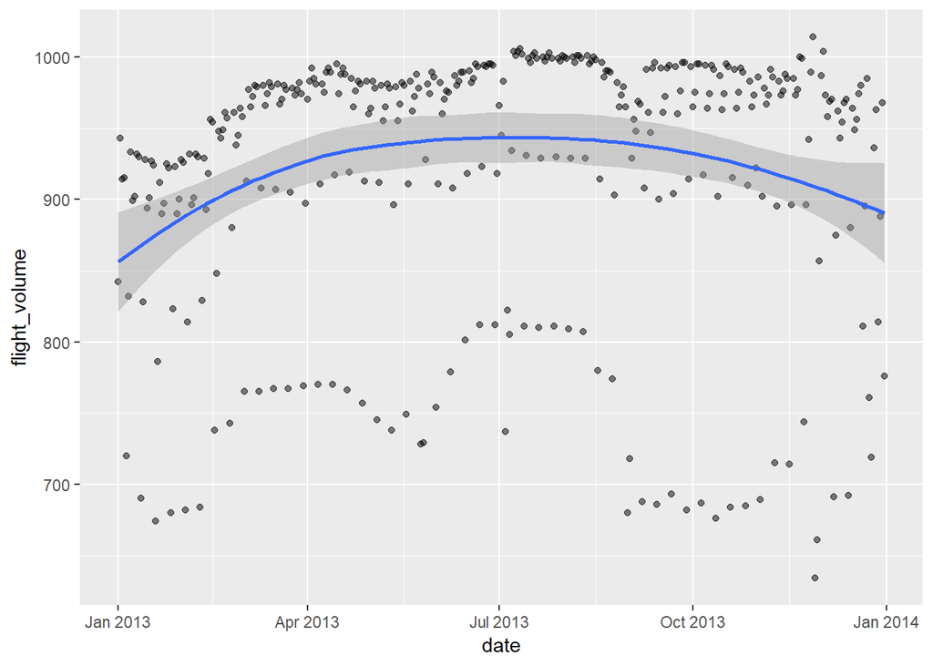

```r
daily %>%
ggplot(mapping = aes(x = date, y = flight_volume)) +
  geom_point(alpha = 0.5) +
  geom_smooth()
```

The spikes look like days of week where people do not travel as much.

## Day of Week

We need an analysis of the distribution of flights by day of the week.

First, make a day of week variable.

```r
# wday() function returns day of week

daily <- daily %>%
  mutate(wday = wday(date, label = T))

print(daily)
```

```
## # A tibble: 365 x 3
##    date       flight_volume wday
##    <date>             <int> <ord>
##  1 2013-11-28           634 Thu
##  2 2013-11-29           661 Fri
##  3 2013-01-19           674 Sat
##  4 2013-10-12           676 Sat
##  5 2013-01-26           680 Sat
##  6 2013-08-31           680 Sat
##  7 2013-02-02           682 Sat
##  8 2013-09-28           682 Sat
##  9 2013-02-09           684 Sat
## 10 2013-10-19           684 Sat
## # ... with 355 more rows
```

### Distribution

Now, let’s plot boxplots showing the different distributions by day of week.

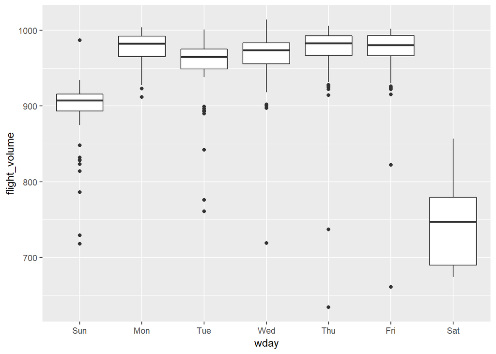

```r
daily %>%
  ggplot(mapping = aes(x = wday, y = flight_volume)) +
  geom_boxplot()
```

It appears that not many people travel on Saturday. The distribution is wider on Saturday just because you have a smaller number of flights.

## Controlling for day of week effect

Preform a linear regression and look at the residuals to remove the effect of day of week.

```r
# Create a linear model
model <- lm(flight_volume ~ wday, data = daily)
```

Add residuals to dataset

```r
daily <- daily %>%
  add_residuals(model)

daily
```

```
## # A tibble: 365 x 4
##    date       flight_volume wday   resid
##    <date>             <int> <ord>  <dbl>
##  1 2013-11-28           634 Thu   -332.
##  2 2013-11-29           661 Fri   -306.
##  3 2013-01-19           674 Sat    -70.6
##  4 2013-10-12           676 Sat    -68.6
##  5 2013-01-26           680 Sat    -64.6
##  6 2013-08-31           680 Sat    -64.6
##  7 2013-02-02           682 Sat    -62.6
##  8 2013-09-28           682 Sat    -62.6
##  9 2013-02-09           684 Sat    -60.6
## 10 2013-10-19           684 Sat    -60.6
## # ... with 355 more rows
```

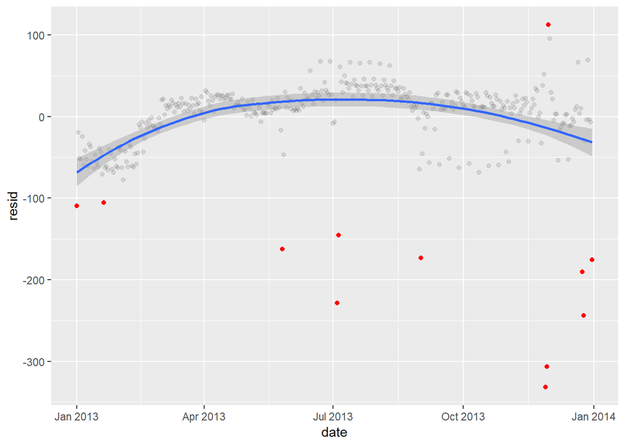

```r
daily %>%
ggplot(mapping = aes(x=date, y=resid)) +
  geom_point(alpha=0.1) +
  geom_point(filter(daily,abs(resid)>100), mapping = aes(x=date,y=resid), color="red") +
  geom_smooth()
```

Points in red are very unusual. Negative numbers mean days with unusually low flight volume even accounting for day of week effect. (These days are holidays?)

Get data for multiple year and see if this trend follows.